# Gender Ideologies and Language Processing: A Self-Paced Reading Time Study

B. Papineau

2021

# 1 Introduction

This document contains the results and analysis of my first experiment for my first Qualifying Paper towards the PhD in Linguistics at Stanford University[^1].

# 2 Methods

## 2.1 The Experiment

The experiment analyzed herein was an online self-paced reading task study, wherein participants read a sentence such as “David is a congressperson from Virginia. He likes cycling.” For each of the 20 critical items, participants were randomly assigned to one of four conditions, the critical regions of which are enumerated and exemplified here:

1. Male-congruent: *David is a congressman*
2. Male-neutral: *David is a congressperson*
3. Female-congruent: *Sally is a congresswoman*
4. Female-neutral: *Sally is a congressperson*

Participants proceeded through the sentences by pressing the spacebar and reading one word or lexical item (such as “Stunt Double”) at a time. They were then asked attention check questions at the end of each sentence; attention check questions never explicitly invoked gender. Rather, they asked about the character’s hobbies or home states. For a hands-on look at the experiment, you can click [here](https://branpap.github.io/gender_processing/experiments/1_Reading_Neutrality/experiment/experiment.html) to go to the same webpage particpants were directed to for the task.

These requirements were implemented in order to assure that speakers came from at least somewhat similar linguistic backgrounds, as certain lexical items in the study (such as *congressperson*) are quite localized to the United States.

After this initial run of the experiment, we found that there was a dearth of conservative or Republican-aligned participants. As a result, we ran the experiment again, this time on 98 self-identified Republicans. This was achieved by adding a filter on Prolific so that only Republican-identified individuals could see the task. The rest of the experiment, including payment, was exactly the same, except that an additional disclaimer that participants could not use the FireFox browser experiment, after the first run revealed an incompatibility between JavaScript and FireFox. The two runs of the experiment amounted in a total of 298 participants who completed the task.

# 3 Prepping the Data

Before we can do much of anything with the data, we need to make sure it’s usable! This means filtering out all unimportant or extraneous trials, running exclusion criteria, and adding additional trial and item-level data that will be necessary later in the analysis.

## 3.1 Packages

For this analysis, we require the following packages:

```r
library(ggplot2)
library(tidyverse)
library(lme4)
library(stringr)
library(languageR)
library(lmerTest)
library(reshape2)
source("helpers.R")
```

## 3.2 Reading in the Data

In the first instance, we need to read in the data, which has been pre-merged from both runs of the experiment. We will also in this chunk filter out all of the example trials, as well as all the data points that are from non-critical trials.

```r
all_data <- read.csv('merged_all.csv') %>%
  filter(trial_id!= 'example') %>%
  filter(region=='critical')
```

## 3.3 Running Exclusion Criteria

Now, we want to exclude any participants who failed to answer at least 85% of the attention check questions correctly. We do this by creating a list of all participants who scored less than 85% on these checks, and then cross-referencing this list with all data points, removing any data points whose participants were in the exclusion list.

```r
exclusion <- all_data %>% group_by(workerid) %>%
  summarise(accuracy = mean(response_correct)) %>%
  mutate(exclude = ifelse(accuracy < 0.85,'Yes','No')) %>%
  filter(exclude == 'Yes')

all_data <- all_data[!(all_data$workerid %in% exclusion$workerid),] %>%
  filter(rt !='null')
```

## 3.4 Adding in Additional Important Trial Information

Now that we have only the rows we want, let’s add some new columns, which will contain important information for each data point. Here, we will be adding:

- Gender Ideology Subscores
- Trial Genders
- Trial Morphology Types
- Critical Item Length & Length-Controlled Residuals
- Trial Congruency
- Partipant Political Affiliation

Ideally, I would’ve added all of these but the first when I actually created the stimuli and logged responses, but I forgot to! Luckily, R allows us to do this post-hoc fairly straightforwardly… which is good, since these features will be critical in our data visualization and analysis.

### 3.4.1 Defining Gender Subscores

The question under investigation here is whether or not individuals’ conceptions of gender affect how they process gendered and gender-neutral forms of English personal and professional titles.  
In order to examine this, we need to quanify participants’ ideological views! Here we have adopted the 13-item Social Roles Questionnaire put forth in Baber & Tucker (2006). Questions 1-5 correlate to the *‘Gender Transcendent’* subscale, and questions 6-13 correspond to the *‘Gender Linked’* subscale. Each item is scored on a scale of 0-100. So, the first thing we want to do is make two lists of columns which correspond to these two subscales, since the questions are stored individually in the data:

```r
gender_transcendence_cols <- c('subject_information.gender_q1','subject_information.gender_q2','subject_information.gender_q3','subject_information.gender_q4','subject_information.gender_q5')

gender_linked_cols <- c('subject_information.gender_q6','subject_information.gender_q7','subject_information.gender_q8','subject_information.gender_q9','subject_information.gender_q10','subject_information.gender_q11','subject_information.gender_q12','subject_information.gender_q13')
```

Now we can use the mutate() method on **all_data** to add two new columns, one for each subscale. We tell R to take the means of the specified columns in [column_names] of **all_data** for each individual row: rowMeans(all_data[column_names]). We also have to subtract this mean from 100 in the case of the *‘Gender Transcendent’* subscale, since it is inversely scored. Finally, we can create an average total score regardless of subscores, simply by meaning the two subscores we already have.

```r
all_data <- all_data %>%
  mutate(gender_trans = 100 - (rowMeans(all_data[gender_transcendence_cols]))) %>%
  mutate(gender_link = rowMeans(all_data[gender_linked_cols]))

gender_all = c('gender_trans','gender_link')

all_data <- all_data %>%
  mutate(gender_total = rowMeans(all_data[gender_all]))
```

### 3.4.2 Adding Gender

We also want to add whether the trial included a female or male referent (but also, like, destroy the binary!). In order to do this, we’ll just add a **trial_gender** column that says *‘female’* if the condition was either *‘neutral_female’* or *‘congruent_female’*. Otherwise, we want the **trial_gender** to say *‘male’*.

```r
all_data <- all_data %>%
  mutate(trial_gender = ifelse(condition=='neutral_female' | condition == 'congruent_female','female','male'))

all_data %>%
  select(workerid,rt,condition,trial_id,trial_gender)
```

| workerid | rt | condition | trial_id | trial_gender |
| --- | --- | --- | --- | --- |
| 489 | 2532 | neutral_female | congressperson_neutral_female | female |
| 489 | 1526 | congruent_male | meteorologist_congruent_male | male |
| 489 | 1504 | congruent_male | layperson_congruent_male | male |
| 489 | 1305 | congruent_female | anchor_congruent_female | female |
| 489 | 1155 | congruent_female | foreperson_congruent_female | female |
| 489 | 1154 | congruent_female | businessperson_congruent_female | female |
| 489 | 1225 | congruent_male | host_congruent_male | male |
| 489 | 1973 | congruent_female | craftsperson_congruent_female | female |
| 489 | 3743 | neutral_female | camera operator_neutral_female | female |
| 489 | 2524 | neutral_male | firefighter_neutral_male | male |

[output cut: 990 more lines]

### 3.4.3 Adding Morphology Type

Now we want to add whether or not the lexeme’s neutral form is developed by compounding (as in *‘congress-person’*) or by the adoption of the male form (as in *‘actor’* being used more for both men and women). In this study, we only have six lexemes of the latter type, so we’ll just tell R to assign those a **morph_type** value of *‘adoption’* (for ‘male adoption’), and all else will be assigned a value of *‘compound’*.

```r
all_data <- all_data%>%
  mutate(morph_type = ifelse(lexeme!= 'actor' & lexeme!= 'host' & lexeme !='hunter' & lexeme!= 'villain' & lexeme!= 'heir' & lexeme!= 'hero','compound','adoption'))

all_data %>%
  select(rt,lexeme,morph_type)
```

| rt | lexeme | morph_type |
| --- | --- | --- |
| 2532 | congressperson | compound |
| 1526 | meteorologist | compound |
| 1504 | layperson | compound |
| 1305 | anchor | compound |
| 1155 | foreperson | compound |
| 1154 | businessperson | compound |
| 1225 | host | adoption |
| 1973 | craftsperson | compound |
| 3743 | camera operator | compound |
| 2524 | firefighter | compound |

[output cut: 990 more lines]

### 3.4.4 Adding Form Length & Length-Controlled Residuals

Another important factor we want to explore is the length of the critical item! In order to add this, we simply create a new column **form_length** and tell R to input as that column’s value the length of the string that appears in that row’s **form** column, which corresponds to the orthograpic form of the critical item in that trial. *Note that this will include spaces in the count!*

```r
all_data <- all_data %>%
  mutate(form_length = str_length(form))

simple_model <- lm(log(rt)~form_length, data = all_data)

all_data <- all_data %>%
  mutate(resid_rt = resid(simple_model))
```

```r
summary(simple_model)
```

```
Call:
lm(formula = log(rt) ~ form_length, data = all_data)

Residuals:
    Min      1Q  Median      3Q     Max
-0.8837 -0.3067 -0.0704  0.2480  3.1990

Coefficients:
            Estimate Std. Error t value Pr(>|t|)
(Intercept) 6.969210   0.023635 294.863  < 2e-16 ***
form_length 0.011369   0.002428   4.683 2.95e-06 ***
---
Signif. codes:  0 ‘***’ 0.001 ‘**’ 0.01 ‘*’ 0.05 ‘.’ 0.1 ‘ ’ 1

Residual standard error: 0.4301 on 2980 degrees of freedom
Multiple R-squared:  0.007305,  Adjusted R-squared:  0.006972
F-statistic: 21.93 on 1 and 2980 DF,  p-value: 2.954e-06
```

Now that we have these, we can run a simple linear regression which will show us the effect of orthographic length on reading time. Then we add a new column in the data which is the residual reading time, or the reading time in log space AFTER we control for the effects of orthographic length.

### 3.4.5 Adding Congruency Column

We also want to make sure we have a column which records whether or not the trial was gender-congruent (as in *‘Shelby is a congresswoman’*) or gender neutral (as in *‘Shelby is a congressperson’*). We add a **trial_congruency** column, which is valued as *‘congruent’* if that row’s condition is one of the two congruent conditions. Otherwise, it gets valued as *‘neutral’*.

```r
all_data <- all_data %>%
  mutate(trial_congruency = ifelse(condition=='congruent_male' | condition == 'congruent_female','congruent','neutral'))
```

### 3.4.6 Adding Large Political Macrocategories

Finally, we can classify participants by their particular political alignment; we can construe this broadly as “Republicans” vs. “Democrats”, with those who declined to state a preference, or placed themselves in the middle, as “Non-Partisan”.

```r
all_data <- all_data %>%
  mutate(poli_party = ifelse(subject_information.party_alignment == 1 | subject_information.party_alignment == 2,'Republican',ifelse(subject_information.party_alignment == 4 | subject_information.party_alignment == 5,'Democrat','Non-Partisan')))
```

# 4 Data Visualization

Now we can start analysing the data by means of data visualization.

```r
inauguration_2021 = c("#5445b1", "#749dae", "#f3c483", "#5c1a33", "#cd3341","#f7dc6a")
```

## 4.1 Ideology by Age

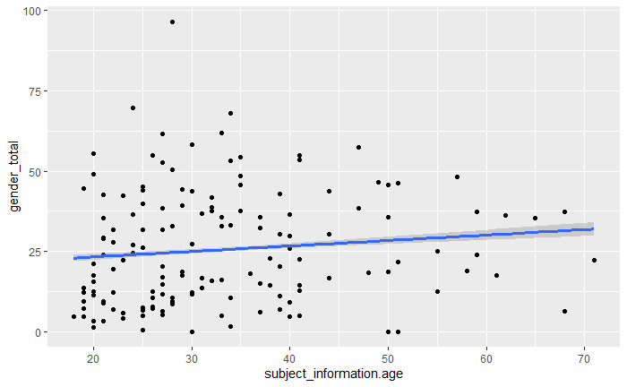

```r
ggplot(all_data, aes(x=subject_information.age, y=gender_total)) +
  geom_point(alpha=.5) +
  geom_smooth(method = 'lm', size=1.2)
```

## 4.2 Reading Time by Gender Ideology

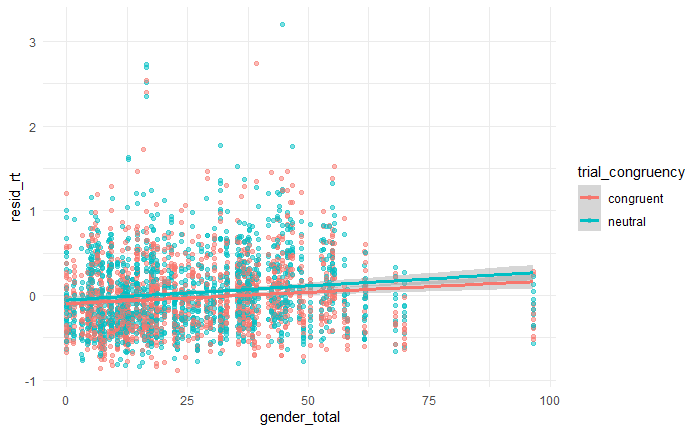

```r
ggplot(all_data, aes(x=gender_total, y=resid_rt, color=trial_congruency)) +
  geom_point(alpha=.5) +
  geom_smooth(method = 'lm', size=1.2) +
  theme_minimal()
```

## 4.3 Reading Time by Age

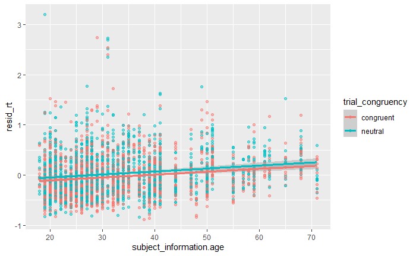

```r
ggplot(all_data, aes(x=subject_information.age, y=resid_rt, color=trial_congruency)) +
  geom_point(alpha=.5) +
  geom_smooth(method = 'lm', size=1.2)
```

## 4.4 Reading Time by Congruency and Gender

```r
agg_speaker_mean_con <- all_data %>%
  group_by(condition,workerid) %>%
  summarize(MeanRT=mean(resid_rt))
```

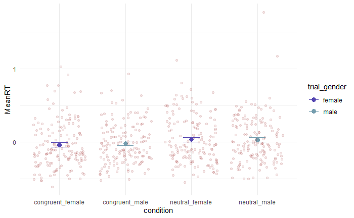

```r
all_data %>%
  group_by(condition,trial_gender) %>%
  summarize(MeanRT = mean(resid_rt), CI.Low = ci.low(resid_rt), CI.High = ci.high(resid_rt)) %>%
  mutate(YMin = MeanRT - CI.Low, YMax = MeanRT + CI.High) %>%
  ggplot(aes(x=condition,y=MeanRT,color=trial_gender)) +
  geom_point(size=3) +
  geom_jitter(data = agg_speaker_mean_con, aes(y=MeanRT),alpha=.1,color='darkred') +
  geom_errorbar(aes(ymin=YMin,ymax=YMax), width=.25) +
  scale_color_manual(values = inauguration_2021) +
  theme_minimal()
```

## 4.5 Reading Time by Congruency, Gender, and Lexical Item

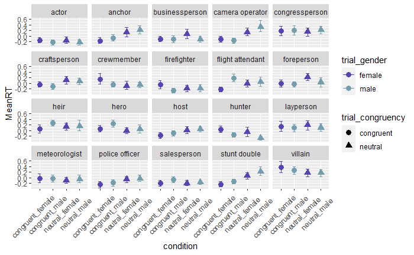

```r
all_data %>%
  group_by(condition,trial_gender,trial_congruency,lexeme) %>%
  summarize(MeanRT = mean(resid_rt), CI.Low = ci.low(resid_rt), CI.High = ci.high(resid_rt)) %>%
  mutate(YMin = MeanRT - CI.Low, YMax = MeanRT + CI.High) %>%
  ggplot(aes(x=condition,y=MeanRT,color=trial_gender,shape=trial_congruency)) +
  geom_point(size=3) +
  geom_errorbar(aes(ymin=YMin,ymax=YMax), width=.25) +
  facet_wrap(~ lexeme) +
  theme(axis.text.x = element_text(angle = 45, vjust = .7, hjust=.7)) +
  scale_color_manual(values = inauguration_2021) +
  facet_wrap(~lexeme)
```

### 4.5.1 Male Adoptions Only

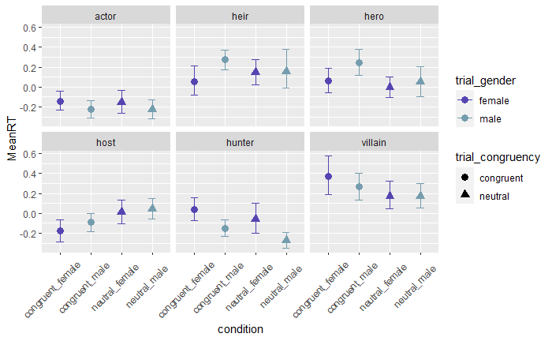

```r
all_data %>%
  filter(morph_type == "adoption") %>%
  group_by(condition,trial_gender,trial_congruency,lexeme) %>%
  summarize(MeanRT = mean(resid_rt), CI.Low = ci.low(resid_rt), CI.High = ci.high(resid_rt)) %>%
  mutate(YMin = MeanRT - CI.Low, YMax = MeanRT + CI.High) %>%
  ggplot(aes(x=condition,y=MeanRT,color=trial_gender,shape=trial_congruency)) +
  geom_point(size=3) +
  geom_errorbar(aes(ymin=YMin,ymax=YMax), width=.25) +
  facet_wrap(~ lexeme) +
  theme(axis.text.x = element_text(angle = 45, vjust = .7, hjust=.7)) +
  scale_color_manual(values = inauguration_2021) +
  facet_wrap(~lexeme)
```

### 4.5.2 Compounds only

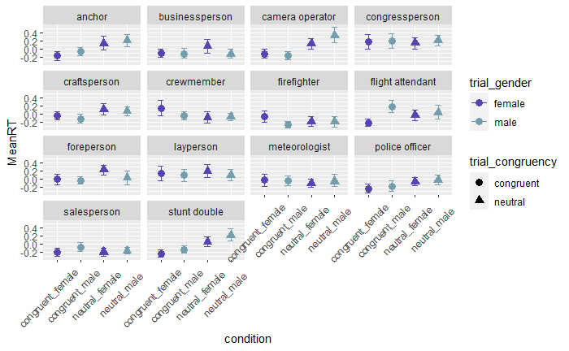

```r
all_data %>%
  filter(morph_type == "compound") %>%
  group_by(condition,trial_gender,trial_congruency,lexeme) %>%
  summarize(MeanRT = mean(resid_rt), CI.Low = ci.low(resid_rt), CI.High = ci.high(resid_rt)) %>%
  mutate(YMin = MeanRT - CI.Low, YMax = MeanRT + CI.High) %>%
  ggplot(aes(x=condition,y=MeanRT,color=trial_gender,shape=trial_congruency)) +
  geom_point(size=3) +
  geom_errorbar(aes(ymin=YMin,ymax=YMax), width=.25) +
  facet_wrap(~ lexeme) +
  theme(axis.text.x = element_text(angle = 45, vjust = .7, hjust=.7)) +
  scale_color_manual(values = inauguration_2021) +
  facet_wrap(~lexeme)
```

## 4.6 Raw Reading Time by Trial Gender

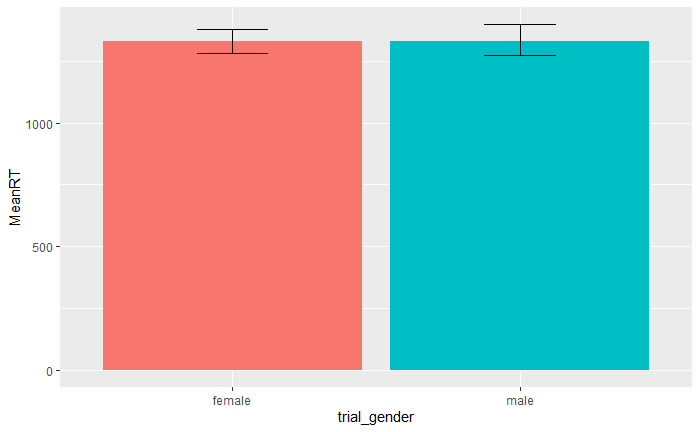

```r
temp <- all_data %>%
  group_by(trial_gender) %>%
  summarize(MeanRT = mean(rt), CI.Low = ci.low(rt), CI.High = ci.high(rt)) %>%
  mutate(YMin = MeanRT - CI.Low, YMax = MeanRT + CI.High)

dodge = position_dodge(.9)
ggplot(data=temp, aes(x=trial_gender,y=MeanRT,fill=trial_gender)) +
  geom_bar(stat='identity',position=dodge) +
  geom_errorbar(aes(ymin=YMin,ymax=YMax),width=.25,position=dodge) +
  theme(legend.position = 'none')
```

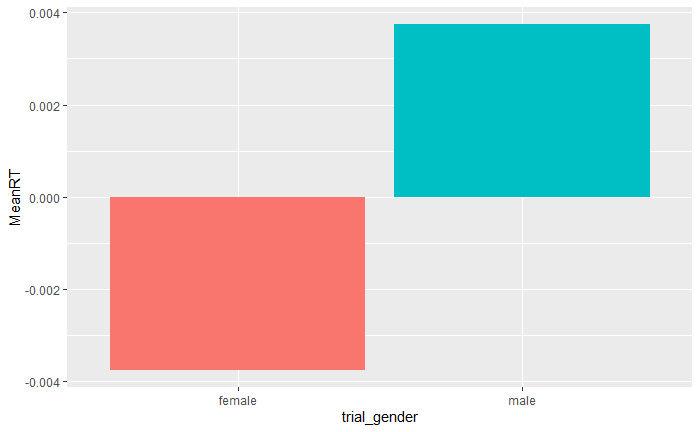

```r
dodge = position_dodge(.9)

all_data %>%
  group_by(trial_gender) %>%
  summarize(MeanRT = mean(resid_rt)) %>%
  ggplot(aes(x=trial_gender,y=MeanRT,fill=trial_gender)) +
  geom_bar(stat='identity',position=dodge) +
  theme(legend.position = 'none')
```

## 4.7 Reading Time Residuals by Congruency

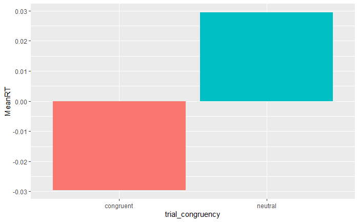

```r
dodge = position_dodge(.9)

all_data %>%
  group_by(trial_congruency) %>%
  summarize(MeanRT = mean(resid_rt)) %>%
  ggplot(aes(x=trial_congruency,y=MeanRT,fill=trial_congruency)) +
  geom_bar(stat='identity',position=dodge) +
  theme(legend.position = 'none')
```

## 4.8 My Morphological Type and Gender

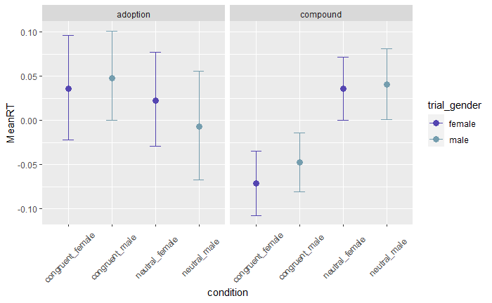

```r
all_data %>%
  group_by(condition,trial_gender,morph_type) %>%
  summarize(MeanRT = mean(resid_rt), CI.Low = ci.low(resid_rt), CI.High = ci.high(resid_rt)) %>%
  mutate(YMin = MeanRT - CI.Low, YMax = MeanRT + CI.High) %>%
  ggplot(aes(x=condition,y=MeanRT,color=trial_gender)) +
  geom_point(size=3) +
  geom_errorbar(aes(ymin=YMin,ymax=YMax), width=.25) +
  scale_color_manual(values = inauguration_2021) +
  facet_wrap(~morph_type) +
  theme(axis.text.x = element_text(angle=45, vjust = 0.5))
```

## 4.9 Task Familiarity

```r
agg_speaker_trial <- all_data %>%
  group_by(condition,workerid) %>%
  summarize(MeanRT=mean(resid_rt))
```

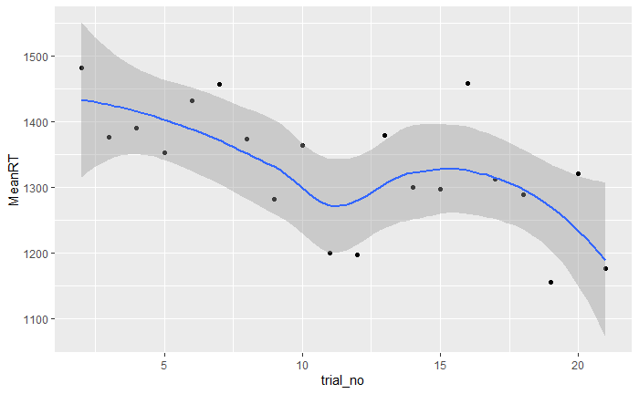

```r
all_data %>%
  group_by(trial_no) %>%
  summarise(MeanRT = mean(rt)) %>%
  ggplot(aes(x=trial_no,y=MeanRT)) +
  geom_point() +
  geom_smooth()
```

# 5 Model Analyses

# 6 Testing Models

```r
test_model <- lm(resid_rt~trial_congruency + morph_type, data=all_data)
```

```r
summary(test_model)
```

[output not shown]

```r
test_model2 <- lm(resid_rt~trial_gender, data=all_data)
```

```r
summary(test_model2)
```

```
Call:
lm(formula = resid_rt ~ trial_gender, data = all_data)

Residuals:
    Min      1Q  Median      3Q     Max
-0.8799 -0.3054 -0.0716  0.2498  3.1953

Coefficients:
                  Estimate Std. Error t value Pr(>|t|)
(Intercept)      -0.003744   0.011138  -0.336    0.737
trial_gendermale  0.007488   0.015751   0.475    0.635

Residual standard error: 0.4301 on 2980 degrees of freedom
Multiple R-squared:  7.583e-05, Adjusted R-squared:  -0.0002597
F-statistic: 0.226 on 1 and 2980 DF,  p-value: 0.6345
```

```r
compounds_only <- all_data %>%
  filter(morph_type == 'compound')
```

```r
compounds_only <- compounds_only %>%
  mutate(ctrial_congruency = as.numeric(as.factor(trial_congruency))-mean(as.numeric(as.factor(trial_congruency)))) %>%
  mutate(ctrial_gender = as.numeric(as.factor(trial_gender))-mean(as.numeric(as.factor(trial_gender)))) %>%
  mutate(cgender_link = scale(gender_link)) %>%
  mutate(cgender_total = scale(gender_total))
```

```r
compound_model <- lmer(resid_rt~ctrial_congruency*ctrial_gender*cgender_total + (1|workerid) + (1|lexeme) + (1|name),data = compounds_only)
```

```
boundary (singular) fit: see ?isSingular
```

```r
summary(compound_model)
```

```
Linear mixed model fit by REML. t-tests use Satterthwaite's method ['lmerModLmerTest']
Formula: resid_rt ~ ctrial_congruency * ctrial_gender * cgender_total +
    (1 | workerid) + (1 | lexeme) + (1 | name)
   Data: compounds_only

REML criterion at convergence: 1516.9

Scaled residuals:
    Min      1Q  Median      3Q     Max
-2.9463 -0.6196 -0.1141  0.5120  5.1743

Random effects:
 Groups   Name        Variance Std.Dev.
 workerid (Intercept) 0.072802 0.26982
 name     (Intercept) 0.000000 0.00000
 lexeme   (Intercept) 0.009709 0.09853
 Residual             0.097840 0.31279
Number of obs: 2089, groups:  workerid, 152; name, 24; lexeme, 14

Fixed effects:
                                                Estimate Std. Error         df t value Pr(>|t|)
(Intercept)                                     -0.01169    0.03492   33.77863  -0.335   0.7398
ctrial_congruency                                0.10120    0.01386 1927.09399   7.301 4.16e-13 ***
ctrial_gender                                    0.02769    0.01387 1927.54232   1.996   0.0461 *
cgender_total                                    0.05201    0.02294  150.06294   2.267   0.0248 *
ctrial_congruency:ctrial_gender                 -0.01774    0.02780 1929.12259  -0.638   0.5234
ctrial_congruency:cgender_total                  0.01692    0.01386 1926.12747   1.221   0.2224
ctrial_gender:cgender_total                     -0.02024    0.01389 1927.94098  -1.457   0.1452
ctrial_congruency:ctrial_gender:cgender_total   -0.04153    0.02776 1927.38754  -1.496   0.1349
---
Signif. codes:  0 ‘***’ 0.001 ‘**’ 0.01 ‘*’ 0.05 ‘.’ 0.1 ‘ ’ 1

Correlation of Fixed Effects:
                 (Intr) ctrl_c ctrl_g cgndr_ ctrl_cngrncy:ct_ ctrl_cngrncy:cg_ ctrl_g:_
ctrl_cngrnc       0.000
ctrial_gndr       0.000 -0.008
cgender_ttl       0.000  0.003 -0.001
ctrl_cngrncy:ct_ -0.002  0.001  0.003  0.001
ctrl_cngrncy:cg_  0.002 -0.006  0.003  0.009 -0.002
ctrl_gndr:_      -0.001  0.005  0.004  0.000  0.016           -0.003
ctrl_cn:_:_       0.001  0.001  0.016 -0.001  0.000            0.000            0.034
optimizer (nloptwrap) convergence code: 0 (OK)
boundary (singular) fit: see ?isSingular
```

```r
adoptions_only <- all_data %>%
  filter(morph_type == 'adoption')
```

```r
adoptions_only <- adoptions_only %>%
  mutate(ctrial_congruency = as.numeric(as.factor(trial_congruency))-mean(as.numeric(as.factor(trial_congruency)))) %>%
  mutate(ctrial_gender = as.numeric(as.factor(trial_gender))-mean(as.numeric(as.factor(trial_gender)))) %>%
  mutate(cgender_link = scale(gender_link)) %>%
  mutate(cgender_total = scale(gender_total))
```

```r
adoptions_model <- lmer(resid_rt~ctrial_congruency*ctrial_gender*cgender_total + (1|workerid) + (1|lexeme) + (1|name),data = adoptions_only)
```

```
boundary (singular) fit: see ?isSingular
```

```r
summary(adoptions_model)
```

```
Linear mixed model fit by REML. t-tests use Satterthwaite's method ['lmerModLmerTest']
Formula: resid_rt ~ ctrial_congruency * ctrial_gender * cgender_total +
    (1 | workerid) + (1 | lexeme) + (1 | name)
   Data: adoptions_only

REML criterion at convergence: 780.7

Scaled residuals:
    Min      1Q  Median      3Q     Max
-2.2764 -0.6128 -0.1019  0.4977  7.0825

Random effects:
 Groups   Name        Variance Std.Dev.
 workerid (Intercept) 0.05999  0.2449
 name     (Intercept) 0.00000  0.0000
 lexeme   (Intercept) 0.02594  0.1611
 Residual             0.10261  0.3203
Number of obs: 893, groups:  workerid, 152; name, 24; lexeme, 6

Fixed effects:
                                                Estimate Std. Error         df t value Pr(>|t|)
(Intercept)                                     0.026404   0.069521   5.924863   0.380  0.71734
ctrial_congruency                              -0.026661   0.022600 773.237762  -1.180  0.23848
ctrial_gender                                  -0.024247   0.022594 773.262319  -1.073  0.28353
cgender_total                                   0.061983   0.022598 148.801276   2.743  0.00684 **
ctrial_congruency:ctrial_gender                -0.033364   0.045588 779.086714  -0.732  0.46447
ctrial_congruency:cgender_total                -0.009892   0.022408 764.311685  -0.441  0.65901
ctrial_gender:cgender_total                    -0.011764   0.022586 769.611878  -0.521  0.60261
ctrial_congruency:ctrial_gender:cgender_total   0.039454   0.045136 767.084621   0.874  0.38232
---
Signif. codes:  0 ‘***’ 0.001 ‘**’ 0.01 ‘*’ 0.05 ‘.’ 0.1 ‘ ’ 1

Correlation of Fixed Effects:
                 (Intr) ctrl_c ctrl_g cgndr_ ctrl_cngrncy:ct_ ctrl_cngrncy:cg_ ctrl_g:_
ctrl_cngrnc       0.000
ctrial_gndr       0.000  0.029
cgender_ttl      -0.001 -0.008  0.002
ctrl_cngrncy:ct_  0.003  0.001  0.005 -0.008
ctrl_cngrncy:cg_ -0.003 -0.021 -0.013 -0.031  0.020
ctrl_gndr:_       0.001 -0.013  0.002  0.003 -0.005            0.007
ctrl_cn:_:_      -0.003  0.020 -0.003  0.001 -0.007            0.011           -0.057
optimizer (nloptwrap) convergence code: 0 (OK)
boundary (singular) fit: see ?isSingular
```

## 6.1 Full Model

```r
all_data <- all_data %>%
  mutate(ctrial_congruency = as.numeric(as.factor(trial_congruency))-mean(as.numeric(as.factor(trial_congruency)))) %>%
  mutate(ctrial_gender = as.numeric(as.factor(trial_gender))-mean(as.numeric(as.factor(trial_gender)))) %>%
  mutate(cgender_link = scale(gender_link)) %>%
  mutate(cgender_total = scale(gender_total)) %>%
  mutate(cmorph_type = as.numeric(as.factor(morph_type))-mean(as.numeric(as.factor(morph_type))))
```

```r
complex_model <- lmer(resid_rt~ctrial_congruency*ctrial_gender*cgender_total*cmorph_type + (1|workerid) + (1|lexeme) + (1|name),data = all_data)
```

```
boundary (singular) fit: see ?isSingular
```

```r
summary(complex_model)
```

```
Linear mixed model fit by REML. t-tests use Satterthwaite's method ['lmerModLmerTest']
Formula: resid_rt ~ ctrial_congruency * ctrial_gender * cgender_total *
    cmorph_type + (1 | workerid) + (1 | lexeme) + (1 | name)
   Data: all_data

REML criterion at convergence: 2133.4

Scaled residuals:
    Min      1Q  Median      3Q     Max
-2.6102 -0.6295 -0.1159  0.5158  7.9382

Random effects:
 Groups   Name        Variance Std.Dev.
 workerid (Intercept) 0.06836  0.2615
 name     (Intercept) 0.00000  0.0000
 lexeme   (Intercept) 0.01417  0.1190
 Residual             0.09989  0.3161
Number of obs: 2982, groups:  workerid, 152; name, 24; lexeme, 20

Fixed effects:
                                                            Estimate Std. Error         df t value Pr(>|t|)
(Intercept)                                               -9.108e-05  3.452e-02  4.418e+01  -0.003   0.9979
ctrial_congruency                                          5.918e-02  1.161e-02  2.799e+03   5.098 3.65e-07 ***
ctrial_gender                                              8.774e-03  1.161e-02  2.799e+03   0.756   0.4498
cgender_total                                              5.510e-02  2.199e-02  1.500e+02   2.506   0.0133 *
cmorph_type                                               -3.823e-02  5.944e-02  1.800e+01  -0.643   0.5282
ctrial_congruency:ctrial_gender                           -1.956e-02  2.323e-02  2.800e+03  -0.842   0.3997
ctrial_congruency:cgender_total                            1.008e-02  1.163e-02  2.800e+03   0.867   0.3860
ctrial_gender:cgender_total                               -1.850e-02  1.164e-02  2.800e+03  -1.590   0.1120
ctrial_congruency:cmorph_type                              1.342e-01  2.598e-02  2.820e+03   5.168 2.54e-07 ***
ctrial_gender:cmorph_type                                  6.224e-02  2.597e-02  2.820e+03   2.397   0.0166 *
cgender_total:cmorph_type                                 -9.589e-03  1.269e-02  2.798e+03  -0.756   0.4498
ctrial_congruency:ctrial_gender:cgender_total             -1.716e-02  2.327e-02  2.800e+03  -0.737   0.4609
ctrial_congruency:ctrial_gender:cmorph_type                9.142e-03  5.222e-02  2.824e+03   0.175   0.8610
ctrial_congruency:cgender_total:cmorph_type                2.322e-02  2.590e-02  2.815e+03   0.897   0.3699
ctrial_gender:cgender_total:cmorph_type                   -6.000e-03  2.603e-02  2.819e+03  -0.230   0.8177
ctrial_congruency:ctrial_gender:cgender_total:cmorph_type -7.937e-02  5.203e-02  2.818e+03  -1.526   0.1272
---
Signif. codes:  0 ‘***’ 0.001 ‘**’ 0.01 ‘*’ 0.05 ‘.’ 0.1 ‘ ’ 1
```

```
Correlation matrix not shown by default, as p = 16 > 12.
Use print(x, correlation=TRUE)  or
    vcov(x)        if you need it
```

```
optimizer (nloptwrap) convergence code: 0 (OK)
boundary (singular) fit: see ?isSingular
```

```r
ideology_model <- lmer(resid_rt~trial_congruency*ctrial_gender*cgender_link + (1|workerid) + (1|lexeme) + (1|name), data=all_data)
```

```
boundary (singular) fit: see ?isSingular
```

```r
summary(ideology_model)
```

```
Linear mixed model fit by REML. t-tests use Satterthwaite's method ['lmerModLmerTest']
Formula: resid_rt ~ trial_congruency * ctrial_gender * cgender_link +
    (1 | workerid) + (1 | lexeme) + (1 | name)
   Data: all_data

REML criterion at convergence: 2129.1

Scaled residuals:
    Min      1Q  Median      3Q     Max
-2.5813 -0.6321 -0.1304  0.5107  7.6659

Random effects:
 Groups   Name        Variance Std.Dev.
 workerid (Intercept) 0.06754  0.2599
 name     (Intercept) 0.00000  0.0000
 lexeme   (Intercept) 0.01365  0.1168
 Residual             0.10099  0.3178
Number of obs: 2982, groups:  workerid, 152; name, 24; lexeme, 20

Fixed effects:
                                                     Estimate Std. Error         df t value Pr(>|t|)
(Intercept)                                        -3.002e-02  3.457e-02  5.002e+01  -0.868   0.3893
trial_congruencyneutral                             5.968e-02  1.167e-02  2.806e+03   5.116 3.33e-07 ***
ctrial_gender                                       1.852e-02  1.651e-02  2.806e+03   1.122   0.2621
cgender_link                                        5.496e-02  2.261e-02  1.722e+02   2.431   0.0161 *
trial_congruencyneutral:ctrial_gender              -1.761e-02  2.334e-02  2.807e+03  -0.754   0.4507
trial_congruencyneutral:cgender_link                1.229e-02  1.167e-02  2.807e+03   1.053   0.2925
ctrial_gender:cgender_link                         -6.943e-03  1.650e-02  2.807e+03  -0.421   0.6740
trial_congruencyneutral:ctrial_gender:cgender_link -6.519e-03  2.336e-02  2.807e+03  -0.279   0.7802
---
Signif. codes:  0 ‘***’ 0.001 ‘**’ 0.01 ‘*’ 0.05 ‘.’ 0.1 ‘ ’ 1

Correlation of Fixed Effects:
                    (Intr) trl_cn ctrl_g cgndr_ trl_cngrncyntrl:ct_ trl_cngrncyntrl:cg_ ctr_:_
trl_cngrncy         -0.169
ctrial_gndr          0.000 -0.001
cgender_lnk         -0.001  0.001  0.000
trl_cngrncyntrl:ct_  0.000  0.000 -0.707  0.001
trl_cngrncyntrl:cg_  0.001 -0.001  0.001 -0.258 -0.002
ctrl_gndr:_          0.000  0.000 -0.002  0.000  0.001              -0.001
trl_cng:_:_          0.000  0.000  0.002  0.000  0.000               0.000              -0.706
optimizer (nloptwrap) convergence code: 0 (OK)
boundary (singular) fit: see ?isSingular
```

# 7 Comments

```r
all_data %>%
  group_by(workerid,poli_party) %>%
  summarise(comments = paste(unique(subject_information.comments))) %>%
  select(poli_party,comments)
```

| workerid | poli_party | comments |
| --- | --- | --- |
| 472 | Democrat |  |
| 473 | Democrat |  |
| 474 | Democrat |  |
| 475 | Democrat |  |
| 478 | Democrat | I think these kind of decisions aren't black and white and depend more on how society affects different genders. |
| 479 | Democrat |  |
| 481 | Democrat |  |
| 482 | NA |  |
| 483 | Democrat |  |
| 485 | Democrat |  |

[output cut: 142 more lines]

# 8 Testing Grounds

## 8.1 Checking the times

```r
new_toy <- read.csv('maze_task_1-merged.csv') %>%
  filter(trial_id!= 'example') %>%
  filter(response_correct != 0) %>%
  mutate(trial_gender = ifelse(condition=='neutral_female' | condition == 'congruent_female','female','male')) %>%
  mutate(trial_congruency = ifelse(condition=='congruent_male' | condition == 'congruent_female','congruent','neutral'))
```

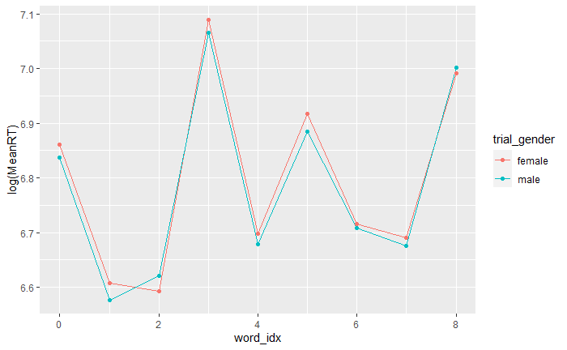

```r
new_toy %>%
  group_by(word_idx,trial_gender) %>%
  summarize(MeanRT = mean(rt)) %>%
  ggplot(aes(x=word_idx, y=log(MeanRT), color=trial_gender)) +
  geom_line() +
  geom_point()
```

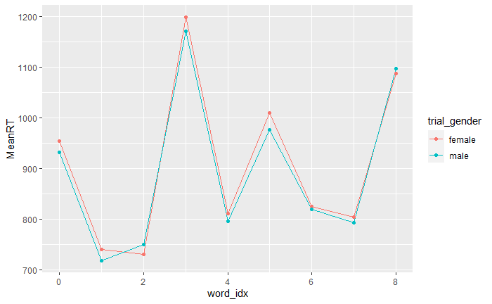

```r
new_toy %>%
  group_by(word_idx,trial_gender) %>%
  summarize(MeanRT = mean(rt)) %>%
  ggplot(aes(x=word_idx, y=MeanRT, color=trial_gender)) +
  geom_line() +
  geom_point()
```

Rscript merge_results.R maze_task_1-merged.csv dems maze_task_2-merged.csv reps

[^1]: Part of this experiment and analysis was also carried out as part of my class project in Stanford’s LINGUIST 245B ‘Methods in Psycholinguistics’ class, taught by Judith Degen.
[^2]: This amounts to an hourly rate of $20.73. We originally anticipated that participants would take an average of 7 minutes to complete the experiment, and set the base pay at $15 an hour.